# Figure7_S21-S22

```r
    interactions$Day7Percentage[i] <- sum(combo7 == 2, na.rm = TRUE)/(length(combo7) - sum(is.na(combo7)))*100
  }
  if (interactions$NMF[i] == "NMF7"){
    interactions$Receptor_LFC[i] <- nmf7_unique$log2FoldChange[which(rownames(nmf7_unique) == interactions$Receptor.ID[i])]
    meantpm <- mean(t(logTPM_select[which(rownames(logTPM_select) == interactions$Receptor.ID[i]),]))
    meannpx <- mean(df.covid.select[,which(colnames(df.covid.select) == interactions$Ligand.ID[i])], na.rm = TRUE)
    tpmtf <- as.numeric(logTPM_select_NMF7[which(rownames(logTPM_select) == interactions$Receptor.ID[i]),] > meantpm)
    npxtf <- as.numeric(df.covid.select.NMF7[,which(colnames(df.covid.select) == interactions$Ligand.ID[i])] > meannpx)
    combo <- tpmtf + npxtf
    interactions$Percentage[i] <- sum(combo == 2, na.rm = TRUE)/(length(combo) - sum(is.na(combo)))*100
    tpmtf0 <- as.numeric(logTPM_select_NMF7_d0[which(rownames(logTPM_select) == interactions$Receptor.ID[i]),] > meantpm)
    npxtf0 <- as.numeric(df.covid.select.NMF7.d0[,which(colnames(df.covid.select) == interactions$Ligand.ID[i])] > meannpx)
    combo0 <- tpmtf0 + npxtf0
    interactions$Day0Percentage[i] <- sum(combo0 == 2, na.rm = TRUE)/(length(combo0) - sum(is.na(combo0)))*100
    tpmtf3 <- as.numeric(logTPM_select_NMF7_d3[which(rownames(logTPM_select) == interactions$Receptor.ID[i]),] > meantpm)
    npxtf3 <- as.numeric(df.covid.select.NMF7.d3[,which(colnames(df.covid.select) == interactions$Ligand.ID[i])] > meannpx)
    combo3 <- tpmtf3 + npxtf3
    interactions$Day3Percentage[i] <- sum(combo3 == 2, na.rm = TRUE)/(length(combo3) - sum(is.na(combo3)))*100
    tpmtf7 <- as.numeric(logTPM_select_NMF7_d7[which(rownames(logTPM_select) == interactions$Receptor.ID[i]),] > meantpm)
    npxtf7 <- as.numeric(df.covid.select.NMF7.d7[,which(colnames(df.covid.select) == interactions$Ligand.ID[i])] > meannpx)
    combo7 <- tpmtf7 + npxtf7
    interactions$Day7Percentage[i] <- sum(combo7 == 2, na.rm = TRUE)/(length(combo7) - sum(is.na(combo7)))*100
  }
}

remove(logTPM_select_NMF1, logTPM_select_NMF1_d0, logTPM_select_NMF1_d3, logTPM_select_NMF1_d7, logTPM_select_NMF2, logTPM_select_NMF2_d0, logTPM_select_NMF2_d3, logTPM_select_NMF2_d7, logTPM_select_NMF3, logTPM_select_NMF3_d0, logTPM_select_NMF3_d3, logTPM_select_NMF3_d7, logTPM_select_NMF4, logTPM_select_NMF4_d0, logTPM_select_NMF4_d3, logTPM_select_NMF4_d7, logTPM_select_NMF5, logTPM_select_NMF5_d0, logTPM_select_NMF5_d3, logTPM_select_NMF5_d7, logTPM_select_NMF6, logTPM_select_NMF6_d0, logTPM_select_NMF6_d3, logTPM_select_NMF6_d7, logTPM_select_NMF7, logTPM_select_NMF7_d0, logTPM_select_NMF7_d3, logTPM_select_NMF7_d7, df.covid.select.NMF1, df.covid.select.NMF1.d0, df.covid.select.NMF1.d3, df.covid.select.NMF1.d7, df.covid.select.NMF2, df.covid.select.NMF2.d0, df.covid.select.NMF2.d3, df.covid.select.NMF2.d7, df.covid.select.NMF3, df.covid.select.NMF3.d0, df.covid.select.NMF3.d3, df.covid.select.NMF3.d7, df.covid.select.NMF4, df.covid.select.NMF4.d0, df.covid.select.NMF4.d3, df.covid.select.NMF4.d7, df.covid.select.NMF5, df.covid.select.NMF5.d0, df.covid.select.NMF5.d3, df.covid.select.NMF5.d7, df.covid.select.NMF6, df.covid.select.NMF6.d0, df.covid.select.NMF6.d3, df.covid.select.NMF6.d7, df.covid.select.NMF7, df.covid.select.NMF7.d0, df.covid.select.NMF7.d3, df.covid.select.NMF7.d7)
```

```r
lrtypes <- read.xlsx(paste0(prefix,"LR_interaction_types_manual.xlsx"))

generateLRplot <- function(cluster,offset){
  storage <- list()

  nmfchoice <- cluster

  # Connecting lines

  nmf_interactions <- interactions[interactions$NMF == nmfchoice,]
  nmf_lines <- nmf_interactions[,colnames(nmf_interactions) %in% c("Pair.Name","Ligand","Receptor","Percentage","Receptor_LFC")]
  nmf_points <- as.data.frame(matrix(0L, nrow = 2*nrow(nmf_lines), ncol = 7))
  colnames(nmf_points) <- c("pair","ligand","receptor","percentage","xval","yval","LFC")
  nmf_points$pair <- rep(nmf_lines$Pair.Name, each = 2)
  nmf_points$ligand <- rep(nmf_lines$Ligand, each = 2)
  nmf_points$receptor <- rep(nmf_lines$Receptor, each = 2)
  nmf_points$percentage <- rep(nmf_lines$Percentage, each = 2)
  nmf_points$LFC <- rep(nmf_lines$LFC, each = 2)
  ligands <- unique(nmf_lines$Ligand[rev(order(nmf_lines$Percentage))])
  ligands <- as.data.frame(cbind(ligands,rev(1:length(ligands))))
  colnames(ligands) <- c("ligandname","ligandorder")
  receptors <- unique(nmf_lines$Receptor[rev(order(nmf_lines$Receptor_LFC))])
  receptors <- as.data.frame(cbind(receptors,rev(1:length(receptors))))
  colnames(receptors) <- c("receptorname","receptororder")

  nmf_points$xval <- rep(c(0,1),nrow(nmf_points)/2)
  for (i in seq(1,nrow(nmf_points),2)){
    nmf_points$yval[i] <- receptors$receptororder[which(receptors$receptorname == nmf_points$receptor[i])]
  }
  for (i in seq(2,nrow(nmf_points),2)){
    nmf_points$yval[i] <- ligands$ligandorder[which(ligands$ligandname == nmf_points$ligand[i])]
  }

  nmf_points$yval[seq(1,nrow(nmf_points),2)] <- as.numeric(nmf_points$yval[seq(1,nrow(nmf_points),2)]) + offset

  storage[[1]] <- as.ggplot(ggplot(nmf_points, aes(x = as.numeric(xval), y = as.numeric(yval))) + geom_line(aes(group = pair)) + theme_bw() + theme(panel.grid = element_blank(), axis.line = element_blank(), panel.border = element_blank(), axis.title = element_blank(), axis.ticks = element_blank(), axis.text = element_blank(), plot.margin = unit(c(1,1,1,1),"lines")) + coord_fixed(ratio = .2, clip = "off") + geom_text(data = subset(nmf_points, xval == "0"), aes(label = receptor), size = 2) + geom_text(data = subset(nmf_points, xval == "1"), aes(label = ligand), size = 2))

  # Ligand Heatmap

  heatdf <- interactions[interactions$NMF == nmfchoice,]
  heatdf <- heatdf[rev(order(heatdf$Percentage)),]
  if (sum(duplicated(heatdf$Ligand.ID)) > 0){
    heatdf <- heatdf[-which(duplicated(heatdf$Ligand.ID)),]
  }
  rownames(heatdf) <- heatdf$Ligand
  heatdf <- heatdf[,c(9,10,11)]
  breaksList = seq(0, 100, by = 0.25)
  storage[[2]] <- as.ggplot(pheatmap(as.matrix(heatdf), scale = "none", cluster_cols = FALSE, cluster_rows = FALSE, color = colorRampPalette(colors = c("#ffffd9","#edf8b1","#c7e9b4","#7fcdbb","#41b6c4","#1d91c0","#225ea8","#253494","#081d58"))(length(breaksList)), breaks = breaksList, cellwidth = 6.8, cellheight = 6.8, fontsize_row = 5, border_color = "black", legend = FALSE, show_colnames = FALSE))

  # Receptor Heatmap

  heatdf <- interactions[interactions$NMF == nmfchoice,]
  heatdf <- heatdf[rev(order(heatdf$Receptor_LFC)),]
  heatdf <- heatdf[-which(duplicated(heatdf$Receptor.ID)),]
  heatdf$dummy <- NA
  rownames(heatdf) <- heatdf$Receptor
  heatdf <- heatdf[,c(12,7)]
  breaksList = seq(0,2, by = 0.01)
  storage[[3]] <- as.ggplot(pheatmap(as.matrix(heatdf), scale = "none", cluster_cols = FALSE, cluster_rows = FALSE, color = colorRampPalette(colors = c("white","#f9f37c","#ff9b35","#bd370a","#5e0000"))(length(breaksList)), breaks = breaksList, cellwidth = 6.8, cellheight = 6.8, fontsize_row = 5, border_color = "black", legend = FALSE, show_colnames = FALSE))

  # Interaction Type
  heatdf <- interactions[interactions$NMF == nmfchoice,]
  heatdf <- heatdf[rev(order(heatdf$Percentage)),]
  if (sum(duplicated(heatdf$Ligand.ID)) > 0){
    heatdf <- heatdf[-which(duplicated(heatdf$Ligand.ID)),]
  }
  heatdf$dummy <- NA
  rownames(heatdf) <- heatdf$Ligand
  heatdf$type <- NA
  for (i in 1:nrow(heatdf)){
    heatdf$type[i] <- lrtypes$Interaction[(which(lrtypes$Pair.Name == heatdf$Pair.Name[i]))]
  }
  heatdf <- heatdf[,c(12,13)]
  heatdf$type <- mapvalues(heatdf$type, from = c("ChemoAdh","CytGro","Both"), to = c(1,2,3))
  breaksList = c(0,1,2,3)
  colors <- c(skyblue,"darkorchid4","darkseagreen4")
  heatdf[,2] <- as.numeric(heatdf[,2])
  storage[[4]] <- as.ggplot(pheatmap(as.matrix(heatdf), scale = "none", cluster_cols = FALSE, cluster_rows = FALSE, breaks = breaksList, color = colors, cellwidth = 6.8, cellheight = 6.8, fontsize_row = 5, border_color = "black", legend = FALSE, show_colnames = FALSE))

  return(storage)
}
```

```r
lrplots1 <- generateLRplot("NMF1",offset=-0.5)
```

```r
lrplots2 <- generateLRplot("NMF2",offset=1)
```

```r
lrplots3 <- generateLRplot("NMF3",offset=0)
```

```r
lrplots4 <- generateLRplot("NMF4",offset=8.5)
```

```r
lrplots5 <- generateLRplot("NMF5",offset=0.5)
```

**Figure 7A (Without Cell-of-origin):**

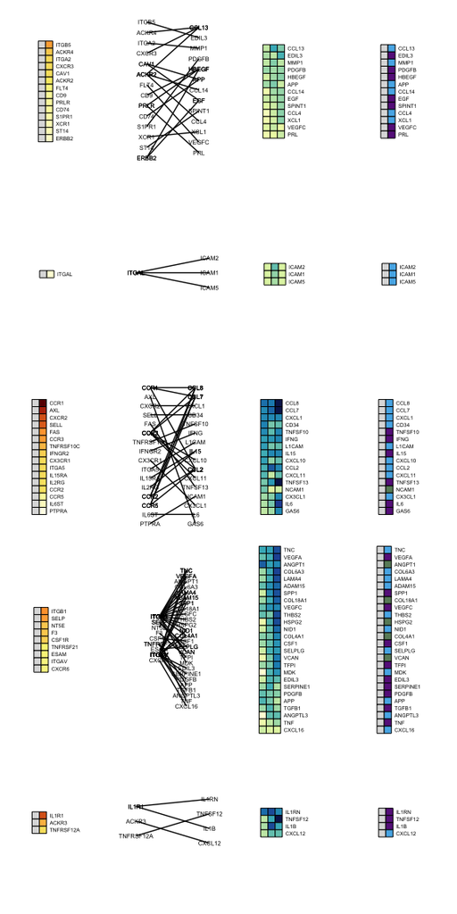

```r
plot_grid(lrplots1[[3]],lrplots1[[1]],lrplots1[[2]],lrplots1[[4]],lrplots2[[3]],lrplots2[[1]],lrplots2[[2]],lrplots2[[4]],lrplots3[[3]],lrplots3[[1]],lrplots3[[2]],lrplots3[[4]],lrplots4[[3]],lrplots4[[1]],lrplots4[[2]],lrplots4[[4]],lrplots5[[3]],lrplots5[[1]],lrplots5[[2]],lrplots5[[4]],ncol = 4)
```

Then we repeat this analysis for severity on Days 0, 3, and 7 separately.

First is Day 0.

```r
df.covid.select <- df.covid.w[df.covid.w$COVID == "Positive" & df.covid.w$Day %in% c("D0"),]
logTPM_select <- logTPM_filtered[,which(colnames(logTPM_filtered) %in% df.covid.select$Public.Sample.ID),]
metadata_select <- metadata_filtered[metadata_filtered$Public.Sample.ID %in% colnames(logTPM_select),]

lrdatabase <- read.delim(paste0(prefix,"LR-database_fantom.txt"))
lrdatabase <- lrdatabase[lrdatabase$Pair.Evidence %in% c("literature supported","putative"),]
lrdatabase <- lrdatabase[,colnames(lrdatabase) %in% c("Pair.Name","Ligand.ApprovedSymbol","Receptor.ApprovedSymbol")]
colnames(lrdatabase) <- c("Pair.Name","Ligand","Receptor")
lrdatabase <- lrdatabase[lrdatabase$Ligand %in% c(uniprotOlink$Assay,"DEFA1","DEFA1B","MICB","MICA","CKMT1A","CKMT1B","FUT3","FUT5","EBI3","IL27","DEFB4A","DEFB4B","IL12A","IL12B","LGALS7","LGALS7B"),]

res <- read.xlsx(paste0(prefix,"Tables/TableS2.xlsx"), sheet = 5)
res <- res[rev(order(res$rank)),]
severe <- res[res$padj < 0.05 & res$rank > 0,]
nonsevere <- res[res$padj < 0.05 & res$rank < 0,]
severe$cluster <- "severe"
severe <- severe[severe$symbol %in% lrdatabase$Receptor,]
nonsevere$cluster <- "nonsevere"
nonsevere <- nonsevere[nonsevere$symbol %in% lrdatabase$Receptor,]

severe_unique <- severe[!(severe$symbol %in% rbind(nonsevere)$symbol),]
severe_interactions <- lrdatabase[lrdatabase$Receptor %in% severe_unique$symbol,]
severe_interactions <- severe_interactions[!(severe_interactions$Receptor %in% hpa0$Gene.name),]
severe_interactions$Ligand <- mapvalues(severe_interactions$Ligand, from = c("DEFA1","DEFA1B","MICB","MICA","CKMT1A","CKMT1B","FUT3","FUT5","EBI3","IL27","DEFB4A","DEFB4B","IL12A","IL12B","LGALS7","LGALS7B"), to = c("DEFA1_DEFA1B","DEFA1_DEFA1B","MICB_MICA","MICB_MICA","CKMT1A_CKMT1B","CKMT1A_CKMT1B","FUT3_FUT5","FUT3_FUT5","EBI3_IL27","EBI3_IL27","DEFB4A_DEFB4B","DEFB4A_DEFB4B","IL12A_IL12B","IL12A_IL12B","LGALS7_LGALS7B","LGALS7_LGALS7B"))
severe_interactions$Ligand.ID <- matrix(0L, nrow = nrow(severe_interactions), ncol = 1)
severe_interactions$Receptor.ID <- matrix(0L, nrow = nrow(severe_interactions), ncol = 1)
for (i in 1:nrow(severe_interactions)){
  severe_interactions$Ligand.ID[i] <- uniprotOlink$OlinkID[which(uniprotOlink$Assay == severe_interactions$Ligand[i])]
  severe_interactions$Receptor.ID[i] <- temp$Gene.stable.ID[which(temp$Gene.name == severe_interactions$Receptor[i])]
}

nonsevere_unique <- nonsevere[!(nonsevere$symbol %in% rbind(severe)$symbol),]
nonsevere_interactions <- lrdatabase[lrdatabase$Receptor %in% nonsevere_unique$symbol,]
nonsevere_interactions <- nonsevere_interactions[!(nonsevere_interactions$Receptor %in% hpa0$Gene.name),]
nonsevere_interactions$Ligand <- mapvalues(nonsevere_interactions$Ligand, from = c("DEFA1","DEFA1B","MICB","MICA","CKMT1A","CKMT1B","FUT3","FUT5","EBI3","IL27","DEFB4A","DEFB4B","IL12A","IL12B","LGALS7","LGALS7B"), to = c("DEFA1_DEFA1B","DEFA1_DEFA1B","MICB_MICA","MICB_MICA","CKMT1A_CKMT1B","CKMT1A_CKMT1B","FUT3_FUT5","FUT3_FUT5","EBI3_IL27","EBI3_IL27","DEFB4A_DEFB4B","DEFB4A_DEFB4B","IL12A_IL12B","IL12A_IL12B","LGALS7_LGALS7B","LGALS7_LGALS7B"))
nonsevere_interactions$Ligand.ID <- matrix(0L, nrow = nrow(nonsevere_interactions), ncol = 1)
nonsevere_interactions$Receptor.ID <- matrix(0L, nrow = nrow(nonsevere_interactions), ncol = 1)
for (i in 1:nrow(nonsevere_interactions)){
  nonsevere_interactions$Ligand.ID[i] <- uniprotOlink$OlinkID[which(uniprotOlink$Assay == nonsevere_interactions$Ligand[i])]
  nonsevere_interactions$Receptor.ID[i] <- temp$Gene.stable.ID[which(temp$Gene.name == nonsevere_interactions$Receptor[i])]
}

proteins <- names(df.covid.select)[!(names(df.covid.select) %in% c(colnames(metadata_filtered),"nmf1","nmf2","nmf3","nmf4","nmf5","nmf6","nmf7"))]

storage <- list()
for(i in proteins){
  storage[[i]] <- wilcox.test(get(i) ~ severity.max, df.covid.select)
}
volcano <- as.data.frame(matrix(0L, nrow = length(storage), ncol = 5))
colnames(volcano) <- c("pval","lfc","padj","rank","protein")
rownames(volcano) <- proteins
for (i in 1:nrow(volcano)){
  volcano$pval[i] <- storage[[i]]$p.value
  volcano$lfc[i] <- mean(df.covid.select[df.covid.select$severity.max == "severe",colnames(df.covid.select) == rownames(volcano)[i]], na.rm = TRUE) - mean(df.covid.select[df.covid.select$severity.max == "non-severe",colnames(df.covid.select) == rownames(volcano)[i]], na.rm = TRUE)
  volcano$protein[i] <- uniprotOlink$Assay[which(uniprotOlink$OlinkID == rownames(volcano)[i])]
}
volcano$padj <- p.adjust(volcano$pval, method = "fdr")
volcano$rank <- -1*sign(volcano$lfc)*log10(volcano$pval)
volcano <- volcano[rev(order(volcano$rank)),]
volcanofull <- volcano
volcano$significance <- as.numeric(volcano$padj < 0.05)

volcanosevere <- volcano[volcano$rank > 0 & volcano$significance == 1,]
severe_hits <- severe_interactions[severe_interactions$Ligand %in% volcanosevere$protein,]
severe_hits$severity <- "severe"

colnames(severe_hits)[colnames(severe_hits) == "log2FoldChange_severe_nonsevere"] <- "log2FoldChange"

volcanononsevere <- volcano[volcano$rank < 0 & volcano$significance == 1,]
nonsevere_hits <- nonsevere_interactions[nonsevere_interactions$Ligand %in% volcano2$protein,]
nonsevere_hits$severity <- "nonsevere"

colnames(nonsevere_hits)[colnames(nonsevere_hits) == "log2FoldChange_severe_nonsevere"] <- "log2FoldChange"

interactions <- rbind(severe_hits,nonsevere_hits)

logTPM_select_severe <- logTPM_select[,colnames(logTPM_select) %in% metadata_select$Public.Sample.ID[metadata_select$severity.max == "severe"]]
logTPM_select_nonsevere <- logTPM_select[,colnames(logTPM_select) %in% metadata_select$Public.Sample.ID[metadata_select$severity.max == "non-severe"]]

df.covid.select.severe <- df.covid.select[df.covid.select$severity.max == "severe",]
df.covid.select.nonsevere <- df.covid.select[df.covid.select$severity.max == "non-severe",]

interactions$Receptor_LFC <- matrix(0L, nrow = nrow(interactions), ncol = 1)
interactions$Percentage <- matrix(0L, nrow = nrow(interactions), ncol = 1)
for (i in 1:nrow(interactions)){
  if (interactions$severity[i] == "severe"){
    interactions$Receptor_LFC[i] <- severe_unique$log2FoldChange[which(severe_unique$Gene.ID == interactions$Receptor.ID[i])]
    meantpm <- mean(t(logTPM_select[which(rownames(logTPM_select) == interactions$Receptor.ID[i]),]))
    meannpx <- mean(df.covid.select[,which(colnames(df.covid.select) == interactions$Ligand.ID[i])], na.rm = TRUE)
    tpmtf <- as.numeric(logTPM_select_severe[which(rownames(logTPM_select) == interactions$Receptor.ID[i]),] > meantpm)
    npxtf <- as.numeric(df.covid.select.severe[,which(colnames(df.covid.select) == interactions$Ligand.ID[i])] > meannpx)
    combo <- tpmtf + npxtf
    interactions$Percentage[i] <- sum(combo == 2, na.rm = TRUE)/(length(combo) - sum(is.na(combo)))*100
  }
  if (interactions$severity[i] == "nonsevere"){
    interactions$Receptor_LFC[i] <- nonsevere_unique$log2FoldChange[which(nonsevere_unique$Gene.ID == interactions$Receptor.ID[i])]
    meantpm <- mean(t(logTPM_select[which(rownames(logTPM_select) == interactions$Receptor.ID[i]),]))
    meannpx <- mean(df.covid.select[,which(colnames(df.covid.select) == interactions$Ligand.ID[i])], na.rm = TRUE)
    tpmtf <- as.numeric(logTPM_select_nonsevere[which(rownames(logTPM_select) == interactions$Receptor.ID[i]),] > meantpm)
    npxtf <- as.numeric(df.covid.select.nonsevere[,which(colnames(df.covid.select) == interactions$Ligand.ID[i])] > meannpx)
    combo <- tpmtf + npxtf
    interactions$Percentage[i] <- sum(combo == 2, na.rm = TRUE)/(length(combo) - sum(is.na(combo)))*100
  }
}

remove(logTPM_select_severe, logTPM_select_nonsevere, df.covid.select.severe, df.covid.select.nonsevere)
```

```r
severityLRplot <- function(severitychoice,offset){
  storage <- list()

  severitychoice <- severitychoice

  # Connecting lines

  severity_interactions <- interactions[interactions$severity == severitychoice,]
  severity_lines <- severity_interactions[,colnames(severity_interactions) %in% c("Pair.Name","Ligand","Receptor","Percentage","Receptor_LFC")]
  severity_points <- as.data.frame(matrix(0L, nrow = 2*nrow(severity_lines), ncol = 7))
  colnames(severity_points) <- c("pair","ligand","receptor","percentage","xval","yval","LFC")
  severity_points$pair <- rep(severity_lines$Pair.Name, each = 2)
  severity_points$ligand <- rep(severity_lines$Ligand, each = 2)
  severity_points$receptor <- rep(severity_lines$Receptor, each = 2)
  severity_points$percentage <- rep(severity_lines$Percentage, each = 2)
  severity_points$LFC <- rep(severity_lines$LFC, each = 2)
  ligands <- unique(severity_lines$Ligand[rev(order(severity_lines$Percentage))])
  ligands <- as.data.frame(cbind(ligands,rev(1:length(ligands))))
  colnames(ligands) <- c("ligandname","ligandorder")
  receptors <- unique(severity_lines$Receptor[rev(order(abs(severity_lines$Receptor_LFC)))])
  receptors <- as.data.frame(cbind(receptors,rev(1:length(receptors))))
  colnames(receptors) <- c("receptorname","receptororder")

  severity_points$xval <- rep(c(0,1),nrow(severity_points)/2)
  for (i in seq(1,nrow(severity_points),2)){
    severity_points$yval[i] <- receptors$receptororder[which(receptors$receptorname == severity_points$receptor[i])]
  }
  for (i in seq(2,nrow(severity_points),2)){
    severity_points$yval[i] <- ligands$ligandorder[which(ligands$ligandname == severity_points$ligand[i])]
  }

  severity_points$yval[seq(1,nrow(severity_points),2)] <- as.numeric(severity_points$yval[seq(1,nrow(severity_points),2)]) + offset

  storage[[1]] <- as.ggplot(ggplot(severity_points, aes(x = as.numeric(xval), y = as.numeric(yval))) + geom_line(aes(group = pair)) + theme_bw() + theme(panel.grid = element_blank(), axis.line = element_blank(), panel.border = element_blank(), axis.title = element_blank(), axis.ticks = element_blank(), axis.text = element_blank(), plot.margin = unit(c(1,1,1,1),"lines")) + coord_fixed(ratio = .2, clip = "off") + geom_text(data = subset(severity_points, xval == "0"), aes(label = receptor), size = 2) + geom_text(data = subset(severity_points, xval == "1"), aes(label = ligand), size = 2))

  # Ligand Heatmap

  heatdf <- interactions[interactions$severity == severitychoice,]
  heatdf <- heatdf[rev(order(heatdf$Percentage)),]
  if (sum(duplicated(heatdf$Ligand.ID)) > 0){
    heatdf <- heatdf[-which(duplicated(heatdf$Ligand.ID)),]
  }
  rownames(heatdf) <- heatdf$Ligand
  heatdf <- heatdf[,c(8,6)]
  breaksList = seq(0, 100, by = 0.25)
  heatdf[,1] <- as.numeric(heatdf[,1])
  heatdf[,2] <- NA
  storage[[2]] <- as.ggplot(pheatmap(as.matrix(heatdf), scale = "none", cluster_cols = FALSE, cluster_rows = FALSE, color = colorRampPalette(colors = c("#ffffd9","#edf8b1","#c7e9b4","#7fcdbb","#41b6c4","#1d91c0","#225ea8","#253494","#081d58"))(length(breaksList)), breaks = breaksList, cellwidth = 6.8, cellheight = 6.8, fontsize_row = 5, border_color = "black", legend = FALSE, show_colnames = FALSE))

  # Receptor Heatmap

  heatdf <- interactions[interactions$severity == severitychoice,]
  heatdf$Receptor_LFC <- abs(heatdf$Receptor_LFC)
  heatdf <- heatdf[rev(order(heatdf$Receptor_LFC)),]
  heatdf <- heatdf[-which(duplicated(heatdf$Receptor.ID)),]
  heatdf$dummy <- NA
  rownames(heatdf) <- heatdf$Receptor
  heatdf <- heatdf[,c(7,9)]
  breaksList = seq(0,2, by = 0.01)
  storage[[3]] <- as.ggplot(pheatmap(as.matrix(heatdf), scale = "none", cluster_cols = FALSE, cluster_rows = FALSE, color = colorRampPalette(colors = c("white","#f9f37c","#ff9b35","#bd370a","#5e0000"))(length(breaksList)), breaks = breaksList, cellwidth = 6.8, cellheight = 6.8, fontsize_row = 5, border_color = "black", legend = FALSE, show_colnames = FALSE))

  # Interaction Type
  heatdf <- interactions[interactions$severity == severitychoice,]
  heatdf <- heatdf[rev(order(heatdf$Percentage)),]
  if (sum(duplicated(heatdf$Ligand.ID)) > 0){
    heatdf <- heatdf[-which(duplicated(heatdf$Ligand.ID)),]
  }
  heatdf$dummy <- NA
  rownames(heatdf) <- heatdf$Ligand
  heatdf$type <- NA
  for (i in 1:nrow(heatdf)){
    heatdf$type[i] <- lrtypes$Interaction[(which(lrtypes$Pair.Name == heatdf$Pair.Name[i]))]
  }
  heatdf <- heatdf[,c(10,9)]
  heatdf$type <- mapvalues(heatdf$type, from = c("ChemoAdh","CytGro","Both"), to = c(1,2,3))
  breaksList = c(0,1,2,3)
  colors <- c(skyblue,"darkorchid4","darkseagreen4")
  heatdf[,1] <- as.numeric(heatdf[,1])
  storage[[4]] <- as.ggplot(pheatmap(as.matrix(heatdf), scale = "none", cluster_cols = FALSE, cluster_rows = FALSE, breaks = breaksList, color = colors, cellwidth = 6.8, cellheight = 6.8, fontsize_row = 5, border_color = "black", legend = FALSE, show_colnames = FALSE))

  return(storage)
}
```

```r
lrplotsD0severe <- severityLRplot("severe",offset=4)
```

```r
lrplotsD0nonsevere <- severityLRplot("nonsevere",offset=10)
```

**Figure 7B (Without Cell-of-origin):**

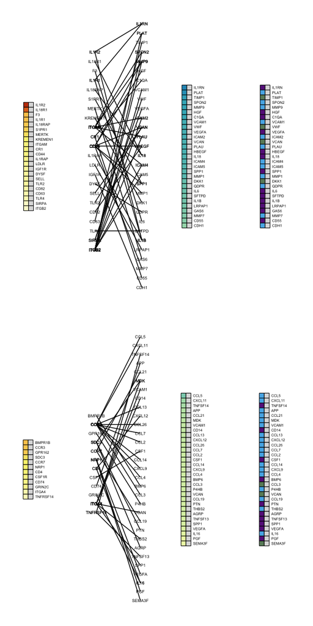

```r
plot_grid(lrplotsD0severe[[3]],lrplotsD0severe[[1]],lrplotsD0severe[[2]],lrplotsD0severe[[4]],lrplotsD0nonsevere[[3]],lrplotsD0nonsevere[[1]],lrplotsD0nonsevere[[2]],lrplotsD0nonsevere[[4]],ncol = 4)
```

Next is Day 3.

```r
df.covid.select <- df.covid.w[df.covid.w$COVID == "Positive" & df.covid.w$Day %in% c("D3"),]
logTPM_select <- logTPM_filtered[,which(colnames(logTPM_filtered) %in% df.covid.select$Public.Sample.ID),]
metadata_select <- metadata_filtered[metadata_filtered$Public.Sample.ID %in% colnames(logTPM_select),]

lrdatabase <- read.delim(paste0(prefix,"LR-database_fantom.txt"))
lrdatabase <- lrdatabase[lrdatabase$Pair.Evidence %in% c("literature supported","putative"),]
lrdatabase <- lrdatabase[,colnames(lrdatabase) %in% c("Pair.Name","Ligand.ApprovedSymbol","Receptor.ApprovedSymbol")]
colnames(lrdatabase) <- c("Pair.Name","Ligand","Receptor")
lrdatabase <- lrdatabase[lrdatabase$Ligand %in% c(uniprotOlink$Assay,"DEFA1","DEFA1B","MICB","MICA","CKMT1A","CKMT1B","FUT3","FUT5","EBI3","IL27","DEFB4A","DEFB4B","IL12A","IL12B","LGALS7","LGALS7B"),]

res <- read.xlsx(paste0(prefix,"Tables/TableS2.xlsx"), sheet = 8)
res <- res[rev(order(res$rank)),]
severe <- res[res$padj < 0.05 & res$rank > 0,]
nonsevere <- res[res$padj < 0.05 & res$rank < 0,]
severe$cluster <- "severe"
severe <- severe[severe$symbol %in% lrdatabase$Receptor,]
nonsevere$cluster <- "nonsevere"
nonsevere <- nonsevere[nonsevere$symbol %in% lrdatabase$Receptor,]

severe_unique <- severe[!(severe$symbol %in% rbind(nonsevere)$symbol),]
severe_interactions <- lrdatabase[lrdatabase$Receptor %in% severe_unique$symbol,]
severe_interactions <- severe_interactions[!(severe_interactions$Receptor %in% hpa0$Gene.name),]
severe_interactions$Ligand <- mapvalues(severe_interactions$Ligand, from = c("DEFA1","DEFA1B","MICB","MICA","CKMT1A","CKMT1B","FUT3","FUT5","EBI3","IL27","DEFB4A","DEFB4B","IL12A","IL12B","LGALS7","LGALS7B"), to = c("DEFA1_DEFA1B","DEFA1_DEFA1B","MICB_MICA","MICB_MICA","CKMT1A_CKMT1B","CKMT1A_CKMT1B","FUT3_FUT5","FUT3_FUT5","EBI3_IL27","EBI3_IL27","DEFB4A_DEFB4B","DEFB4A_DEFB4B","IL12A_IL12B","IL12A_IL12B","LGALS7_LGALS7B","LGALS7_LGALS7B"))
severe_interactions$Ligand.ID <- matrix(0L, nrow = nrow(severe_interactions), ncol = 1)
severe_interactions$Receptor.ID <- matrix(0L, nrow = nrow(severe_interactions), ncol = 1)
for (i in 1:nrow(severe_interactions)){
  severe_interactions$Ligand.ID[i] <- uniprotOlink$OlinkID[which(uniprotOlink$Assay == severe_interactions$Ligand[i])]
  severe_interactions$Receptor.ID[i] <- temp$Gene.stable.ID[which(temp$Gene.name == severe_interactions$Receptor[i])]
}

nonsevere_unique <- nonsevere[!(nonsevere$symbol %in% rbind(severe)$symbol),]
nonsevere_interactions <- lrdatabase[lrdatabase$Receptor %in% nonsevere_unique$symbol,]
nonsevere_interactions <- nonsevere_interactions[!(nonsevere_interactions$Receptor %in% hpa0$Gene.name),]
nonsevere_interactions$Ligand <- mapvalues(nonsevere_interactions$Ligand, from = c("DEFA1","DEFA1B","MICB","MICA","CKMT1A","CKMT1B","FUT3","FUT5","EBI3","IL27","DEFB4A","DEFB4B","IL12A","IL12B","LGALS7","LGALS7B"), to = c("DEFA1_DEFA1B","DEFA1_DEFA1B","MICB_MICA","MICB_MICA","CKMT1A_CKMT1B","CKMT1A_CKMT1B","FUT3_FUT5","FUT3_FUT5","EBI3_IL27","EBI3_IL27","DEFB4A_DEFB4B","DEFB4A_DEFB4B","IL12A_IL12B","IL12A_IL12B","LGALS7_LGALS7B","LGALS7_LGALS7B"))
nonsevere_interactions$Ligand.ID <- matrix(0L, nrow = nrow(nonsevere_interactions), ncol = 1)
nonsevere_interactions$Receptor.ID <- matrix(0L, nrow = nrow(nonsevere_interactions), ncol = 1)
for (i in 1:nrow(nonsevere_interactions)){
  nonsevere_interactions$Ligand.ID[i] <- uniprotOlink$OlinkID[which(uniprotOlink$Assay == nonsevere_interactions$Ligand[i])]
  nonsevere_interactions$Receptor.ID[i] <- temp$Gene.stable.ID[which(temp$Gene.name == nonsevere_interactions$Receptor[i])]
}

proteins <- names(df.covid.select)[!(names(df.covid.select) %in% c(colnames(metadata_filtered),"nmf1","nmf2","nmf3","nmf4","nmf5","nmf6","nmf7"))]

storage <- list()
for(i in proteins){
  storage[[i]] <- wilcox.test(get(i) ~ severity.max, df.covid.select)
}
volcano <- as.data.frame(matrix(0L, nrow = length(storage), ncol = 5))
colnames(volcano) <- c("pval","lfc","padj","rank","protein")
rownames(volcano) <- proteins
for (i in 1:nrow(volcano)){
  volcano$pval[i] <- storage[[i]]$p.value
  volcano$lfc[i] <- mean(df.covid.select[df.covid.select$severity.max == "severe",colnames(df.covid.select) == rownames(volcano)[i]], na.rm = TRUE) - mean(df.covid.select[df.covid.select$severity.max == "non-severe",colnames(df.covid.select) == rownames(volcano)[i]], na.rm = TRUE)
  volcano$protein[i] <- uniprotOlink$Assay[which(uniprotOlink$OlinkID == rownames(volcano)[i])]
}
volcano$padj <- p.adjust(volcano$pval, method = "fdr")
volcano$rank <- -1*sign(volcano$lfc)*log10(volcano$pval)
volcano <- volcano[rev(order(volcano$rank)),]
volcanofull <- volcano
volcano$significance <- as.numeric(volcano$padj < 0.05)

volcanosevere <- volcano[volcano$rank > 0 & volcano$significance == 1,]
severe_hits <- severe_interactions[severe_interactions$Ligand %in% volcanosevere$protein,]
severe_hits$severity <- "severe"

colnames(severe_hits)[colnames(severe_hits) == "log2FoldChange_severe_nonsevere"] <- "log2FoldChange"

volcanononsevere <- volcano[volcano$rank < 0 & volcano$significance == 1,]
nonsevere_hits <- nonsevere_interactions[nonsevere_interactions$Ligand %in% volcano2$protein,]
nonsevere_hits$severity <- "nonsevere"

colnames(nonsevere_hits)[colnames(nonsevere_hits) == "log2FoldChange_severe_nonsevere"] <- "log2FoldChange"

interactions <- rbind(severe_hits,nonsevere_hits)

logTPM_select_severe <- logTPM_select[,colnames(logTPM_select) %in% metadata_select$Public.Sample.ID[metadata_select$severity.max == "severe"]]
logTPM_select_nonsevere <- logTPM_select[,colnames(logTPM_select) %in% metadata_select$Public.Sample.ID[metadata_select$severity.max == "non-severe"]]

df.covid.select.severe <- df.covid.select[df.covid.select$severity.max == "severe",]
df.covid.select.nonsevere <- df.covid.select[df.covid.select$severity.max == "non-severe",]

interactions$Receptor_LFC <- matrix(0L, nrow = nrow(interactions), ncol = 1)
interactions$Percentage <- matrix(0L, nrow = nrow(interactions), ncol = 1)
for (i in 1:nrow(interactions)){
  if (interactions$severity[i] == "severe"){
    interactions$Receptor_LFC[i] <- severe_unique$log2FoldChange[which(severe_unique$Gene.ID == interactions$Receptor.ID[i])]
    meantpm <- mean(t(logTPM_select[which(rownames(logTPM_select) == interactions$Receptor.ID[i]),]))
    meannpx <- mean(df.covid.select[,which(colnames(df.covid.select) == interactions$Ligand.ID[i])], na.rm = TRUE)
    tpmtf <- as.numeric(logTPM_select_severe[which(rownames(logTPM_select) == interactions$Receptor.ID[i]),] > meantpm)
    npxtf <- as.numeric(df.covid.select.severe[,which(colnames(df.covid.select) == interactions$Ligand.ID[i])] > meannpx)
    combo <- tpmtf + npxtf
    interactions$Percentage[i] <- sum(combo == 2, na.rm = TRUE)/(length(combo) - sum(is.na(combo)))*100
  }
  if (interactions$severity[i] == "nonsevere"){
    interactions$Receptor_LFC[i] <- nonsevere_unique$log2FoldChange[which(nonsevere_unique$Gene.ID == interactions$Receptor.ID[i])]
    meantpm <- mean(t(logTPM_select[which(rownames(logTPM_select) == interactions$Receptor.ID[i]),]))
    meannpx <- mean(df.covid.select[,which(colnames(df.covid.select) == interactions$Ligand.ID[i])], na.rm = TRUE)
    tpmtf <- as.numeric(logTPM_select_nonsevere[which(rownames(logTPM_select) == interactions$Receptor.ID[i]),] > meantpm)
    npxtf <- as.numeric(df.covid.select.nonsevere[,which(colnames(df.covid.select) == interactions$Ligand.ID[i])] > meannpx)
    combo <- tpmtf + npxtf
    interactions$Percentage[i] <- sum(combo == 2, na.rm = TRUE)/(length(combo) - sum(is.na(combo)))*100
  }
}

remove(logTPM_select_severe, logTPM_select_nonsevere, df.covid.select.severe, df.covid.select.nonsevere)

lrplotsD3severe <- severityLRplot("severe",offset=8.5)
```

```r
lrplotsD3nonsevere <- severityLRplot("nonsevere",offset=10)
```

**Figure S21A (Without Cell-of-origin):**

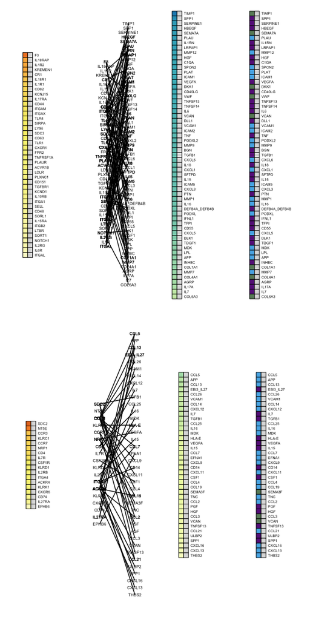

```r
plot_grid(lrplotsD3severe[[3]],lrplotsD3severe[[1]],lrplotsD3severe[[2]],lrplotsD3severe[[4]],lrplotsD3nonsevere[[3]],lrplotsD3nonsevere[[1]],lrplotsD3nonsevere[[2]],lrplotsD3nonsevere[[4]],ncol = 4)
```

Last is Day 7.

```r
df.covid.select <- df.covid.w[df.covid.w$COVID == "Positive" & df.covid.w$Day %in% c("D7"),]
logTPM_select <- logTPM_filtered[,which(colnames(logTPM_filtered) %in% df.covid.select$Public.Sample.ID),]
metadata_select <- metadata_filtered[metadata_filtered$Public.Sample.ID %in% colnames(logTPM_select),]

lrdatabase <- read.delim(paste0(prefix,"LR-database_fantom.txt"))
lrdatabase <- lrdatabase[lrdatabase$Pair.Evidence %in% c("literature supported","putative"),]
lrdatabase <- lrdatabase[,colnames(lrdatabase) %in% c("Pair.Name","Ligand.ApprovedSymbol","Receptor.ApprovedSymbol")]
colnames(lrdatabase) <- c("Pair.Name","Ligand","Receptor")
lrdatabase <- lrdatabase[lrdatabase$Ligand %in% c(uniprotOlink$Assay,"DEFA1","DEFA1B","MICB","MICA","CKMT1A","CKMT1B","FUT3","FUT5","EBI3","IL27","DEFB4A","DEFB4B","IL12A","IL12B","LGALS7","LGALS7B"),]

res <- read.xlsx(paste0(prefix,"Tables/TableS2.xlsx"), sheet = 11)
res <- res[rev(order(res$rank)),]
severe <- res[res$padj < 0.05 & res$rank > 0,]
nonsevere <- res[res$padj < 0.05 & res$rank < 0,]
severe$cluster <- "severe"
severe <- severe[severe$symbol %in% lrdatabase$Receptor,]
nonsevere$cluster <- "nonsevere"
nonsevere <- nonsevere[nonsevere$symbol %in% lrdatabase$Receptor,]

severe_unique <- severe[!(severe$symbol %in% rbind(nonsevere)$symbol),]
severe_interactions <- lrdatabase[lrdatabase$Receptor %in% severe_unique$symbol,]
severe_interactions <- severe_interactions[!(severe_interactions$Receptor %in% hpa0$Gene.name),]
severe_interactions$Ligand <- mapvalues(severe_interactions$Ligand, from = c("DEFA1","DEFA1B","MICB","MICA","CKMT1A","CKMT1B","FUT3","FUT5","EBI3","IL27","DEFB4A","DEFB4B","IL12A","IL12B","LGALS7","LGALS7B"), to = c("DEFA1_DEFA1B","DEFA1_DEFA1B","MICB_MICA","MICB_MICA","CKMT1A_CKMT1B","CKMT1A_CKMT1B","FUT3_FUT5","FUT3_FUT5","EBI3_IL27","EBI3_IL27","DEFB4A_DEFB4B","DEFB4A_DEFB4B","IL12A_IL12B","IL12A_IL12B","LGALS7_LGALS7B","LGALS7_LGALS7B"))
severe_interactions$Ligand.ID <- matrix(0L, nrow = nrow(severe_interactions), ncol = 1)
severe_interactions$Receptor.ID <- matrix(0L, nrow = nrow(severe_interactions), ncol = 1)
for (i in 1:nrow(severe_interactions)){
  severe_interactions$Ligand.ID[i] <- uniprotOlink$OlinkID[which(uniprotOlink$Assay == severe_interactions$Ligand[i])]
  severe_interactions$Receptor.ID[i] <- temp$Gene.stable.ID[which(temp$Gene.name == severe_interactions$Receptor[i])]
}

nonsevere_unique <- nonsevere[!(nonsevere$symbol %in% rbind(severe)$symbol),]
nonsevere_interactions <- lrdatabase[lrdatabase$Receptor %in% nonsevere_unique$symbol,]
nonsevere_interactions <- nonsevere_interactions[!(nonsevere_interactions$Receptor %in% hpa0$Gene.name),]
nonsevere_interactions$Ligand <- mapvalues(nonsevere_interactions$Ligand, from = c("DEFA1","DEFA1B","MICB","MICA","CKMT1A","CKMT1B","FUT3","FUT5","EBI3","IL27","DEFB4A","DEFB4B","IL12A","IL12B","LGALS7","LGALS7B"), to = c("DEFA1_DEFA1B","DEFA1_DEFA1B","MICB_MICA","MICB_MICA","CKMT1A_CKMT1B","CKMT1A_CKMT1B","FUT3_FUT5","FUT3_FUT5","EBI3_IL27","EBI3_IL27","DEFB4A_DEFB4B","DEFB4A_DEFB4B","IL12A_IL12B","IL12A_IL12B","LGALS7_LGALS7B","LGALS7_LGALS7B"))
nonsevere_interactions$Ligand.ID <- matrix(0L, nrow = nrow(nonsevere_interactions), ncol = 1)
nonsevere_interactions$Receptor.ID <- matrix(0L, nrow = nrow(nonsevere_interactions), ncol = 1)
for (i in 1:nrow(nonsevere_interactions)){
  nonsevere_interactions$Ligand.ID[i] <- uniprotOlink$OlinkID[which(uniprotOlink$Assay == nonsevere_interactions$Ligand[i])]
  nonsevere_interactions$Receptor.ID[i] <- temp$Gene.stable.ID[which(temp$Gene.name == nonsevere_interactions$Receptor[i])]
}

proteins <- names(df.covid.select)[!(names(df.covid.select) %in% c(colnames(metadata_filtered),"nmf1","nmf2","nmf3","nmf4","nmf5","nmf6","nmf7"))]

storage <- list()
for(i in proteins){
  storage[[i]] <- wilcox.test(get(i) ~ severity.max, df.covid.select)
}
volcano <- as.data.frame(matrix(0L, nrow = length(storage), ncol = 5))
colnames(volcano) <- c("pval","lfc","padj","rank","protein")
rownames(volcano) <- proteins
for (i in 1:nrow(volcano)){
  volcano$pval[i] <- storage[[i]]$p.value
  volcano$lfc[i] <- mean(df.covid.select[df.covid.select$severity.max == "severe",colnames(df.covid.select) == rownames(volcano)[i]], na.rm = TRUE) - mean(df.covid.select[df.covid.select$severity.max == "non-severe",colnames(df.covid.select) == rownames(volcano)[i]], na.rm = TRUE)
  volcano$protein[i] <- uniprotOlink$Assay[which(uniprotOlink$OlinkID == rownames(volcano)[i])]
}
volcano$padj <- p.adjust(volcano$pval, method = "fdr")
volcano$rank <- -1*sign(volcano$lfc)*log10(volcano$pval)
volcano <- volcano[rev(order(volcano$rank)),]
volcanofull <- volcano
volcano$significance <- as.numeric(volcano$padj < 0.05)

volcanosevere <- volcano[volcano$rank > 0 & volcano$significance == 1,]
severe_hits <- severe_interactions[severe_interactions$Ligand %in% volcanosevere$protein,]
severe_hits$severity <- "severe"

colnames(severe_hits)[colnames(severe_hits) == "log2FoldChange_severe_nonsevere"] <- "log2FoldChange"

volcanononsevere <- volcano[volcano$rank < 0 & volcano$significance == 1,]
nonsevere_hits <- nonsevere_interactions[nonsevere_interactions$Ligand %in% volcano2$protein,]
nonsevere_hits$severity <- "nonsevere"

colnames(nonsevere_hits)[colnames(nonsevere_hits) == "log2FoldChange_severe_nonsevere"] <- "log2FoldChange"

interactions <- rbind(severe_hits,nonsevere_hits)

logTPM_select_severe <- logTPM_select[,colnames(logTPM_select) %in% metadata_select$Public.Sample.ID[metadata_select$severity.max == "severe"]]
logTPM_select_nonsevere <- logTPM_select[,colnames(logTPM_select) %in% metadata_select$Public.Sample.ID[metadata_select$severity.max == "non-severe"]]

df.covid.select.severe <- df.covid.select[df.covid.select$severity.max == "severe",]
df.covid.select.nonsevere <- df.covid.select[df.covid.select$severity.max == "non-severe",]

interactions$Receptor_LFC <- matrix(0L, nrow = nrow(interactions), ncol = 1)
interactions$Percentage <- matrix(0L, nrow = nrow(interactions), ncol = 1)
for (i in 1:nrow(interactions)){
  if (interactions$severity[i] == "severe"){
    interactions$Receptor_LFC[i] <- severe_unique$log2FoldChange[which(severe_unique$Gene.ID == interactions$Receptor.ID[i])]
    meantpm <- mean(t(logTPM_select[which(rownames(logTPM_select) == interactions$Receptor.ID[i]),]))
    meannpx <- mean(df.covid.select[,which(colnames(df.covid.select) == interactions$Ligand.ID[i])], na.rm = TRUE)
    tpmtf <- as.numeric(logTPM_select_severe[which(rownames(logTPM_select) == interactions$Receptor.ID[i]),] > meantpm)
    npxtf <- as.numeric(df.covid.select.severe[,which(colnames(df.covid.select) == interactions$Ligand.ID[i])] > meannpx)
    combo <- tpmtf + npxtf
    interactions$Percentage[i] <- sum(combo == 2, na.rm = TRUE)/(length(combo) - sum(is.na(combo)))*100
  }
  if (interactions$severity[i] == "nonsevere"){
    interactions$Receptor_LFC[i] <- nonsevere_unique$log2FoldChange[which(nonsevere_unique$Gene.ID == interactions$Receptor.ID[i])]
    meantpm <- mean(t(logTPM_select[which(rownames(logTPM_select) == interactions$Receptor.ID[i]),]))
    meannpx <- mean(df.covid.select[,which(colnames(df.covid.select) == interactions$Ligand.ID[i])], na.rm = TRUE)
    tpmtf <- as.numeric(logTPM_select_nonsevere[which(rownames(logTPM_select) == interactions$Receptor.ID[i]),] > meantpm)
    npxtf <- as.numeric(df.covid.select.nonsevere[,which(colnames(df.covid.select) == interactions$Ligand.ID[i])] > meannpx)
    combo <- tpmtf + npxtf
    interactions$Percentage[i] <- sum(combo == 2, na.rm = TRUE)/(length(combo) - sum(is.na(combo)))*100
  }
}

remove(logTPM_select_severe, logTPM_select_nonsevere, df.covid.select.severe, df.covid.select.nonsevere)

lrplotsD7severe <- severityLRplot("severe",offset=7)
```

```r
lrplotsD7nonsevere <- severityLRplot("nonsevere",offset=6)
```

**Figure S21B (Without Cell-of-origin):**

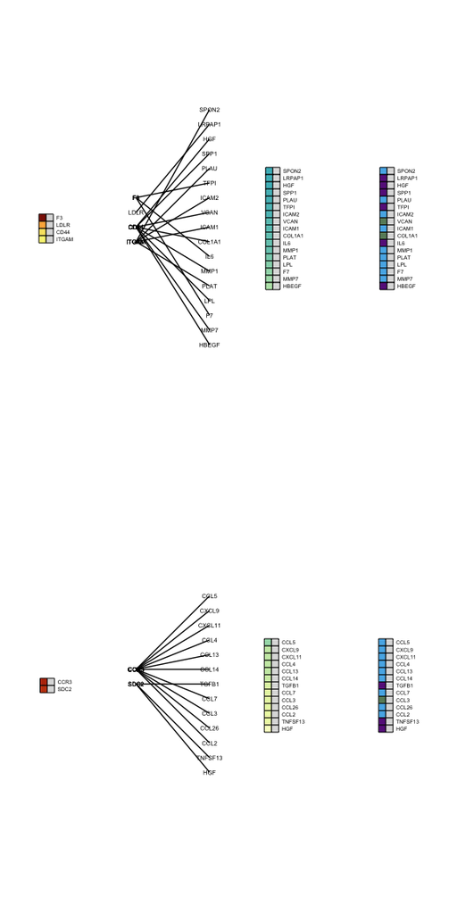

```r
plot_grid(lrplotsD7severe[[3]],lrplotsD7severe[[1]],lrplotsD7severe[[2]],lrplotsD7severe[[4]],lrplotsD7nonsevere[[3]],lrplotsD7nonsevere[[1]],lrplotsD7nonsevere[[2]],lrplotsD7nonsevere[[4]],ncol = 4)
```

Finally, we map each plasma ligand back to an inferred cell-of-origin based on single-cell RNA-sequencing data from BAL fluid of COVID-19-infected lungs from Bost et al. 2020, following the same strategy as described in Filbin et al. 2021.

```r
load(paste0(prefix,"BAL_Bost.RData"))

lrgenes <- unique(c("CXCL12","TNFSF12","IL1B","IL1RN","CXCL16","TNF","ANGPTL3","APP","TGFB1","PDGFB","SERPINE1","EDIL3","MDK","TFPI","VCAN","SELPLG","CSF1","COL4A1","NID1","HSPG2","THBS2","VEGFC","COL18A1","LAMA4","SPP1","ADAM15","COL6A3","ANGPT1","VEGFA","TNC","GAS6","CX3CL1","IL6","NCAM1","TNFSF13","CXCL11","CCL2","CXCL10","IL15","L1CAM","IFNG","TNFSF10","CD34","CXCL1","CCL7","CCL8","ICAM5","ICAM1","ICAM2","PRL","VEGFC","HSPG2","EREG","XCL1","TNFSF11","SPINT1","EGF","APP","CCL14","HBEGF","PDGFB","MMP1","CCL13","IL1RN","PLAT","MMP9","TIMP1","SPON2","HGF","C1QA","VCAM1","VWF","VEGFA","SFTPA1","ICAM2","VCAN","PLAU","HBEGF","IL18","ICAM4","IL1B","ICAM5","SPP1","MMP1","IL6","VIM","DKK1","QDPR","SFTPD","MMP7","LRPAP1","GAS6","CD55","CDH1","CCL5","CXCL11","TNFSF14","CXCL12","CCL21","MDK","APP","VCAM1","CD14","CCL13","PTN","CCL7","CCL2","CSF1","CCL14","CXCL9","CCL4","BMP6","CCL3","P4HB","VCAN","CCL19","THBS2","AGRP","FGF2","TNFSF13","SPP1","VEGFA","IL16","PGF","SEMA3F","SPON2","LRPAP1","HGF","SPP1","PLAU","TFPI","ICAM2","MMP7","VCAN","ICAM1","IL6","COL1A1","FGF2","PLAT","VIM","LPL","F7","HBEGF","CCL5","CXCL9","CCL4","CCL13","CXCL11","CCL14","TGFB1","CCL7","CCL3","CCL2","TNFSF13","FGF2","HGF","TIMP1","SERPINE1","HBEGF","SEMA7A","PLAU","IL1RN","LRPAP1","MMP12","C1QA","SPON2","PLAT","ICAM1","VEGFA","DKK1","CD40LG","VWF","TNFSF14","IL6","VCAN","TNF","DLL1","VCAM1","ICAM2","PODXL2","BGN","DEFB4A","DEFB4B","CSF3","IFNG","TGFB1","CXCL6","IL18","CXCL1","SFTPD","IL15","ICAM5","MMP9","CXCL3","MMP1","IL16","PTN","MMP7","PODXL","IL2","TFPI","CD55","IL1B","IL17A","IFNL1","DLK1","APP","FGF2","MDK","LPL","IL7","INHBC","COL1A1","COL4A1","AGRP","COL6A3","TDGF1","NGF","CCL5","IL2","APP","CCL13","EBI3","IL27","VCAM1","CCL14","TGFB1","CXCL12","IL7","CCL25","IL16","FGF2","MDK","HLA-E","VEGFA","IL15","CCL7","EFNA1","CXCL9","CD14","CXCL11","CSF1","CCL4","CCL19","SEMA3F","TNF","CCL2","HGF","CCL3","VCAN","TNFSF13","PGF","CCL21","ULBP2","SPP1","CXCL16","CXCL13","THBS2"))
seuratcovid <- CreateSeuratObject(counts = plotDefault_exprDF[rownames(plotDefault_exprDF) %in% lrgenes,], project = "COVID", assay = "RNA")
seuratcovid <- AddMetaData(seuratcovid, metadata = subset(plotDefault_samplesDF, select = c("annotation")), col.name = "annotation")
seuratcovid <- subset(seuratcovid, subset = annotation %in% c("Alveolar Macrophages",  "Alveolar Macrophages (MARCOlo)","Alveolar type 2","B cells","CD4+ T cells","CD8+ Trm (ZNF683hi)","Ciliated cells","Club cells","Cytotoxic CD8+ T cells","DC","Effector CD8+ T cells","Epithelial progenitors","Goblet cells","Ionocytes","Mast cells","Mon-derived mac (IL1Bhi)", "Mon-derived mac (SPP1hi C1QAhi)", "Mon-derived mac (SPP1hi C1QAlo)","Monocytes (IFNAhi)","Monocytes I","Monocytes II","Naive CD4+ T cells (CCR7hi)","Neutrophils","NK cells","Plasmacytoid DC (pDC)","Tfh","Tregs"))
seuratcovid <- NormalizeData(seuratcovid)
seuratcovid <- FindVariableFeatures(seuratcovid, selection.method = "vst", nfeatures = 2000)
seuratcovid <- ScaleData(seuratcovid, features = lrgenes)

seuratcovid <- SetIdent(seuratcovid, value = "annotation")
seurataverage <- AverageExpression(seuratcovid, return.seurat=TRUE)
seurataverage <- FindVariableFeatures(seurataverage, selection.method = "vst", nfeatures = 2000)

my_levels <- c("Alveolar Macrophages","Alveolar Macrophages (MARCOlo)","Mon-derived mac (IL1Bhi)","Mon-derived mac (SPP1hi C1QAhi)","Mon-derived mac (SPP1hi C1QAlo)","Monocytes (IFNAhi)","Monocytes I","Monocytes II","Alveolar type 2","Ciliated cells","Club cells","Epithelial progenitors","Goblet cells","Ionocytes","Mast cells","B cells","CD4+ T cells","CD8+ Trm (ZNF683hi)","Cytotoxic CD8+ T cells","Effector CD8+ T cells","Naive CD4+ T cells (CCR7hi)","NK cells","Tfh","Tregs","DC","Plasmacytoid DC (pDC)","Neutrophils")
lineage <- c("Mono/Mac","Mono/Mac","Mono/Mac","Mono/Mac","Mono/Mac","Mono/Mac","Mono/Mac","Mono/Mac","Native Lung Cells","Native Lung Cells","Native Lung Cells","Native Lung Cells","Native Lung Cells","Native Lung Cells","Native Lung Cells","B/Plasma","T/NK","T/NK","T/NK","T/NK","T/NK","T/NK","T/NK","T/NK","DC","DC","Neutrophil")
cell_lineages <- cbind(my_levels,lineage)

df <- seurataverage@assays$RNA@scale.data
df <- df[,my_levels]

celltype <- as.data.frame(matrix(0L, nrow = nrow(df), ncol = 3))
colnames(celltype) <- c("Primary","Secondary","Expression")
rownames(celltype) <- rownames(df)
celltype$Secondary <- NA
for (i in 1:nrow(celltype)){
  celltype$Primary[i] <- colnames(df)[which(df[i,] == max(df[i,]))]
  celltype$Expression[i] <- max(df[i,])
  if ((max(df[i,]) - Rfast::nth(df[i,],2, descending = T)) < 0.1){
    celltype$Secondary[i] <- colnames(df)[which(df[i,] == Rfast::nth(df[i,],2, descending = T))]
  }
}
# Label the secondary cell type in Illustrator only if it is from a different main lineage (e.g. T/NK vs. Mono/Mac)

celltype <- celltype %>%
    arrange(factor(Primary, levels = my_levels), desc(Expression))

seurataverage@active.ident <- factor(x = seurataverage@active.ident, levels = my_levels)
```

**Figure S22:**

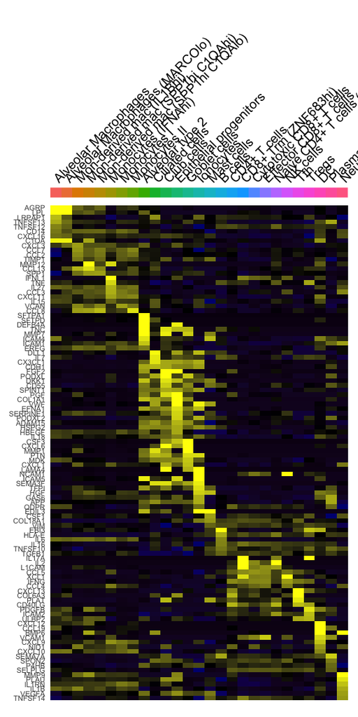

```r
DoHeatmap(seurataverage, raster = FALSE, draw.lines = FALSE, features = rownames(celltype)) + NoLegend() + scale_fill_gradientn(colors = c("navy", "black", "yellow"))
```

Now we can use this information to draw the lines tracing each ligand back to the cell of origin. This was completed in Adobe Illustrator.